# PSICOLOGIA: Investigación y Estadística II

- Profesor: [Dr. José Manuel Magallanes, Ph.D.](http://www.pucp.edu.pe/profesor/jose-manuel-magallanes/)
  - Profesor del Departamento de Ciencias Sociales, Sección de Ciencia Política y Gobierno. Profesor Afiliado del Departamento de Psicología.
  - [Oficina 105](https://goo.gl/maps/xuGeG6o9di1i1y5m6) - Edificio CISEPA / ECONOMIA / CCSS
  - Telefono: (51) 1 - 6262000 anexo 4302
  - Correo Electrónico: jmagallanes@pucp.edu.pe

## Regresión Logística

La data de este material está basada en el trabajo de [Cowles y Davis](https://onlinelibrary.wiley.com/doi/abs/10.1111/j.2044-8309.1987.tb00769.x). Los datos y la metadata están disponibles [aqui](http://vincentarelbundock.github.io/Rdatasets/datasets.html).

Por facilidad puedes verlos aqui en GoogleDocs:

[interactive chart not shown]

Traigamos la data.

Verificamos qué tipo de datos tenemos:

```
## 'data.frame':    1421 obs. of  4 variables:
##  $ neuroticism : int  16 8 5 8 9 6 8 12 15 18 ...
##  $ extraversion: int  13 14 16 20 19 15 10 11 16 7 ...
##  $ sex         : chr  "female" "male" "male" "female" ...
##  $ volunteer   : chr  "no" "no" "no" "no" ...
```

Hay dos columnas que deben ser convertidas a categóricas.

Una vez formateada la data exploremos estadisticamente.

```
##   neuroticism     extraversion       sex      volunteer
##  Min.   : 0.00   Min.   : 2.00   female:780   no :824
##  1st Qu.: 8.00   1st Qu.:10.00   male  :641   yes:597
##  Median :11.00   Median :13.00
##  Mean   :11.47   Mean   :12.37
##  3rd Qu.:15.00   3rd Qu.:15.00
##  Max.   :24.00   Max.   :23.00
```

Las categóricas siempre se almacenan internamente como números, y éstos se asignarán por defecto en orden alfabético. De ahi que el primer nivel de cada categórica se conoce como la **categoría de referencia**.

## 1. Usando la tabla de contingencia

Queremos saber si ser mujer está relacionado con ser voluntario en estudios psicológicos.

```
##          sex
## volunteer female male
##       no     431  393
##       yes    349  248
##       Sum    780  641
```

Saber si ser mujer está relacionado con ser voluntario implica saber dos cosas más:

- Si elijo una mujer a azar, qué probabilidad se tiene que ésta sea voluntaria.
- Cómo comparo el “voluntarismo” de la mujer con la del hombre.

### 1.1. Probabilidades y ODDS

#### A. Caso de la mujer:

- La **probabilidad** que una mujer sea voluntaria, la división del ser voluntaria entre el total de mujeres:

```
## [1] 0.4474359
```

La probabilidad es un valor qu va de 0 a 1. Recuperemos la división así:

```
## [1] 349/780
```

- Representeos el **odds** que sea voluntaria, la división entre ser o no ser voluntaria:

```
## [1] 0.8097448
```

Que se origina de:

```
## [1] 349/431
```

El *odds* suele representarse además como la razón entre dos probabilidades: la probabilidad que ocurra un evento dividido por la probabilidad que NO ocurra ese evento:

```r
OddsMV=probMV/(1-probMV)
OddsMV
```

```
## [1] 0.8097448
```

#### B. Caso del hombre:

- Probabilidad que una hombre sea voluntario

```
## [1] 0.3868955
```

O…

```
## [1] 248/641
```

- El odds que hombre sea voluntario:

```
## [1] 0.6310433
```

O…

```
## [1] 248/393
```

#### C. Comparando Mujer y Hombre:

Para saber qué diferencia produce el sexo en el voluntariado, podemos dividir los odds, lo que nos da el **odds ratio**:

```r
OddsMV/OddsHV
```

```
## [1] 1.283184
```

Con ese valor, ya sabemos que ser mujer participa más en voluntariado que los hombres. El odds ratio (OR) puede ir de 0 a infinito. Un OR de 1 implica que no hay diferencias.

```
## [1] 137157/106888
```

Esto informa que la cantidad de mujeres que encontrarias de voluntarias ante una cantidad de hombres voluntarios.

### 1.2. Porcentajes y gráficas

Veamos la tabla de contingencia con los porcentajes por columna:

```
##          sex
## volunteer    female      male
##       no  0.5525641 0.6131045
##       yes 0.4474359 0.3868955
```

Grafiquemoslo:

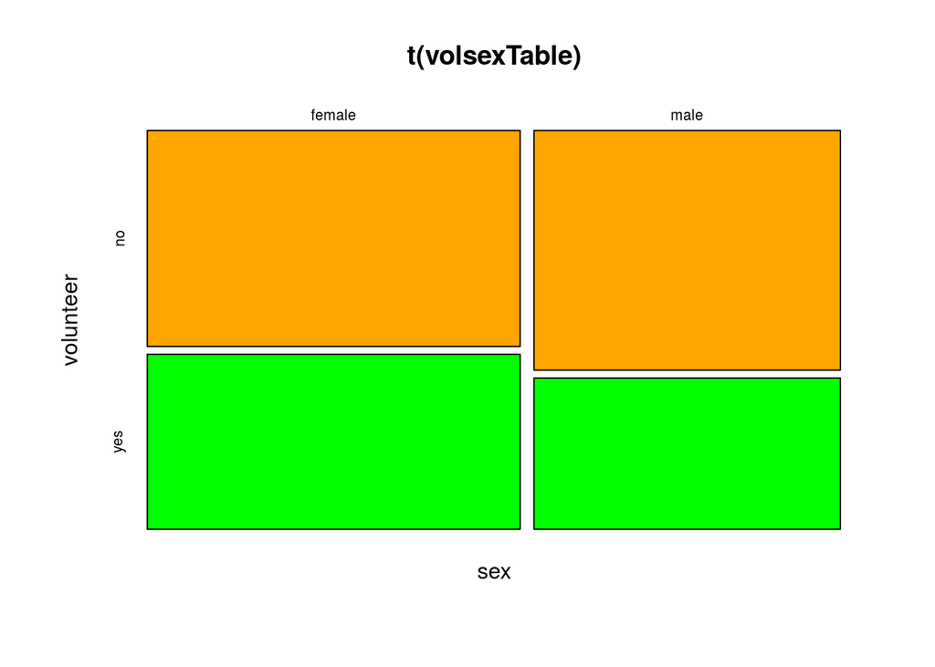

A pesar de la diferencia, ¿será ésta significativa?

## 2. Regresión Logística

La regresión logística modela el comportamiento de la probabilidad del evento de interés:

$${log}(\frac{{p}}{{1 – p}}) = \beta_0 + \beta_ix_i$$

La parte izquierda representa esa probabilidad pero en término del odds. La parte derecha de la ecuación es igual a la ecuación de una recta, pero estamos modelando al logaritmo del odds.

|  | *Dependent variable:* |
| --- | --- |
|  | volunteer |
| sexmale | -0.249** |
|  | (0.108) |
| Constant | -0.211*** |
|  | (0.072) |
| Observations | 1,421 |
| Log Likelihood | -964.101 |
| Akaike Inf. Crit. | 1,932.202 |
| *Note:* | p<0.1; p<0.05; p<0.01 |

Los coeficientes, como se vió en la ecuación anterior, están modelando al logaritmo del odds de ser voluntario.

El resultado anterior ha usado a mujer como referencia: cuanto afecta al log odds de ser voluntario el ser hombre en comparación con ser mujer (la referencia). Ahora sabes que ser hombre disminuye la probabilidad de ser voluntario. Ajustemos la referencia para ver el efecto de mujer:

|  | *Dependent variable:* |
| --- | --- |
|  | volunteer |
| sexfemale | 0.249** |
|  | (0.108) |
| Constant | -0.460*** |
|  | (0.081) |
| Observations | 1,421 |
| Log Likelihood | -964.101 |
| Akaike Inf. Crit. | 1,932.202 |
| *Note:* | p<0.1; p<0.05; p<0.01 |

Vemos que sexo tiene efecto, y el simbolo del coeficiente propone que el efecto es positivo. Ese valor como modela a un logaritmo no es fácil de interpretar. Pero, si le aplicas exponencial, hallarás un valor conocido:

```
## sexfemale
##  1.283184
```

Ahora sabemos que el efecto de sexo es significativo gracias a la regresión logística, algo que no teníamos con las tablas de contingencia.

Además, con la regresión logística podemos tener predictores numéricos, lo que escapa de la utilidad de las tablas de contingencia:

Veamos todos:

|  | *Dependent variable:* |  |  |
| --- | --- | --- | --- |
|  | volunteer |  |  |
|  | (1) | (2) | (3) |
| sexfemale | 0.2** | 0.2** | 0.2** |
|  | (0.1) | (0.1) | (0.1) |
| neuroticism |  | 0.001 | 0.01 |
|  |  | (0.01) | (0.01) |
| extraversion |  |  | 0.1*** |
|  |  |  | (0.01) |
| Constant | -0.5*** | -0.5*** | -1.4*** |
|  | (0.1) | (0.1) | (0.2) |
| Observations | 1421 | 1421 | 1421 |
| Log Likelihood | -964.1 | -964.1 | -953.0 |
| Akaike Inf. Crit. | 1932.2 | 1934.2 | 1914.1 |
| *Note:* | p<0.1; p<0.05; p<0.01 |  |  |

Parece que el modelo 2 no es adecuado, revisemos usando el likelihood ratio test (que reemplaza al anova):

```
## Likelihood ratio test
##
## Model 1: volunteer ~ sex
## Model 2: volunteer ~ sex + neuroticism
## Model 3: volunteer ~ sex + neuroticism + extraversion
##   #Df  LogLik Df   Chisq Pr(>Chisq)
## 1   2 -964.10
## 2   3 -964.10  1  0.0034     0.9537
## 3   4 -953.03  1 22.1372  2.538e-06 ***
## ---
## Signif. codes:  0 '***' 0.001 '**' 0.01 '*' 0.05 '.' 0.1 ' ' 1
```

Como el tercero es el mejor, obtengamos sus coeficientes en odds ratio:

```
##                     OR     2.5 %    97.5 %
## (Intercept)  0.2588109 0.1611002 0.4126864
## sexfemale    1.2651130 1.0176880 1.5738158
## neuroticism  1.0063822 0.9842301 1.0290632
## extraversion 1.0685744 1.0392856 1.0990708
```

### Evaluando

Calculemos las probabilidades predecidas:

Veamos la matriz de confusión:

```
##    no yes
## 0 736 509
## 1  88  88
```

La antidiagonal debería ser 0s si fuera una predicción perfecta.

## Resumenes gráficos

Veamos la relación de extraversión y sexo con la predicción:

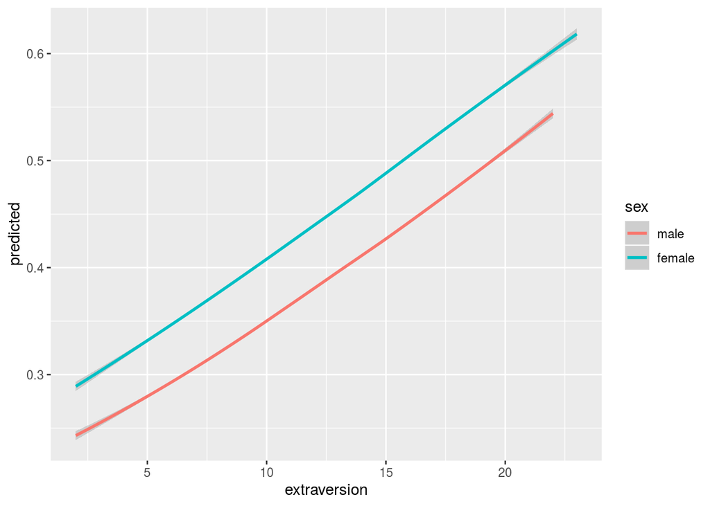

Veamos la relación de neuroticismo y sexo con la predicción:

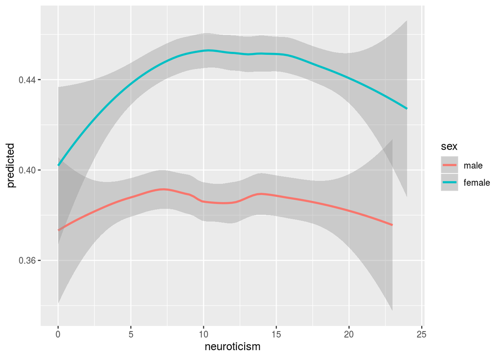

El efecto no es lineal, por lo que le damos una mirada a la interección:

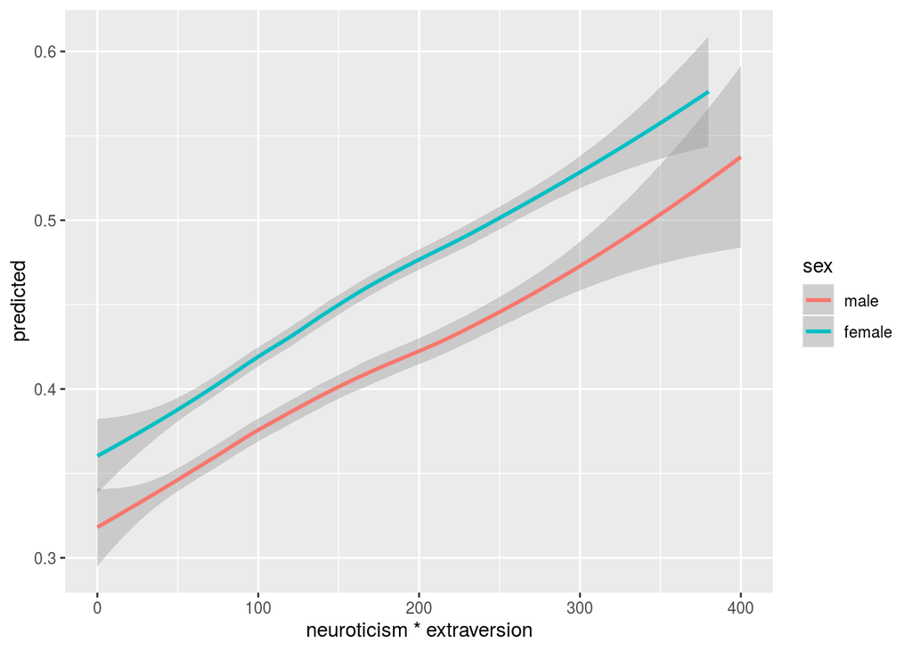

Evaluemos si los valores de neuroticism están relacionados con los de extraversion

|  | *Dependent variable:* |
| --- | --- |
|  | volunteer |
| sexfemale | 0.247** |
|  | (0.112) |
| neuroticism | 0.111*** |
|  | (0.038) |
| extraversion | 0.167*** |
|  | (0.038) |
| neuroticism:extraversion | -0.009*** |
|  | (0.003) |
| Constant | -2.605*** |
|  | (0.501) |
| Observations | 1,421 |
| Log Likelihood | -948.720 |
| Akaike Inf. Crit. | 1,907.440 |
| *Note:* | p<0.1; p<0.05; p<0.01 |

Pues parece que si:

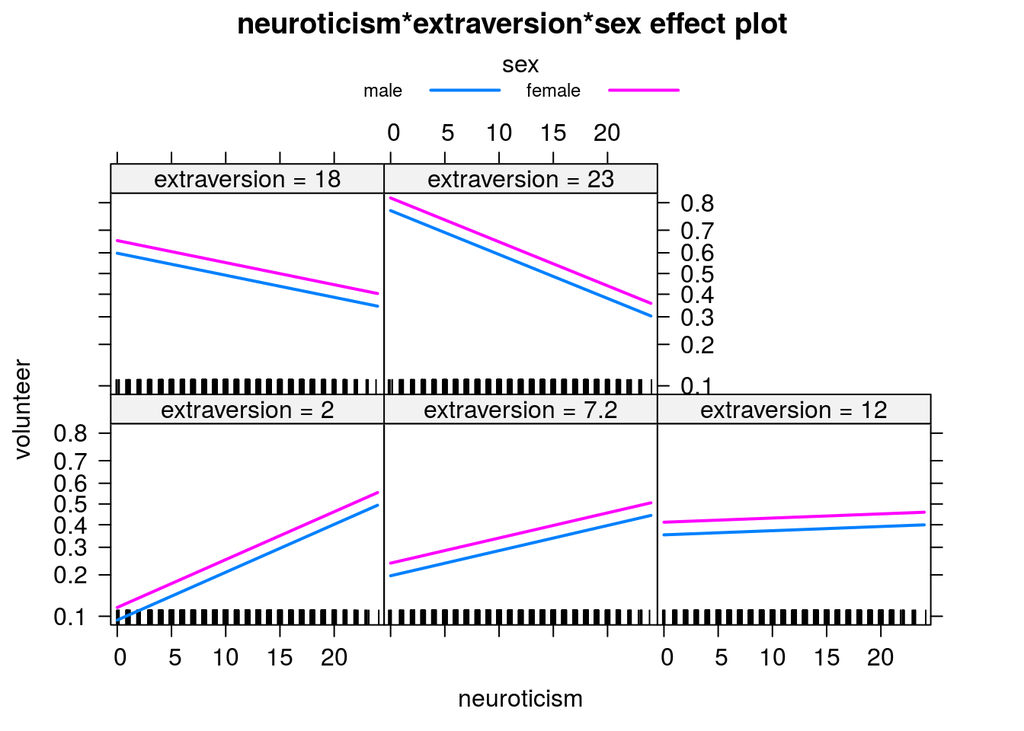

Nos quedaremos con este modelo si es realmente mejor:

```
## Likelihood ratio test
##
## Model 1: volunteer ~ sex + neuroticism + extraversion
## Model 2: volunteer ~ sex + neuroticism * extraversion
##   #Df  LogLik Df  Chisq Pr(>Chisq)
## 1   4 -953.03
## 2   5 -948.72  1 8.6213   0.003323 **
## ---
## Signif. codes:  0 '***' 0.001 '**' 0.01 '*' 0.05 '.' 0.1 ' ' 1
```

Siendo que sí lo es, preparemos las ecuaciones:

$$Pr(VOLUNT=1|X_i) = {\frac{exp(\beta_0 + \beta_1SEX + \beta_2NEU + \beta_3EXTRAV + \beta_4EXTRAV*NEU)}{1 + exp (\beta_0 + \beta_1SEX + \beta_2NEU + \beta_3EXTRAV + \beta_4EXTRAV*NEU)}}$$

Evaluamos nuevamente:

```
##    no yes
## 0 743 499
## 1  81  98
```

La mejora se nota en la matriz de confusión.

## Predicciones

Predecir probabilidad de voluntariado de una mujer con nivel de neuroticismo=13 y extraversion=8:

```
##        1
## 0.383898
```

Predecir probabilidad de voluntariado de una mujer y hombre con los mismos niveles anteriores de neuroticismo y extraversion.

```
##         1         2
## 0.3838980 0.3273516
```

[output not shown]